# Índice Sintético de Desigualdad Migratoria (ISDM). Argentina y Chile, 2015-2024

Metodología, resultados y pruebas de robustez

Natalia Debandi (CONICET – CIAI-UNSAM)

23/11/2026

# 1 Presentación

Este documento reúne la metodología completa del Índice Sintético de Desigualdad Migratoria (ISDM), todos sus resultados y las pruebas de robustez, para Argentina y Chile entre 2015 y 2024. Acompaña al artículo «Brechas de acceso a derechos entre población migrante y no migrante en Argentina y Chile (2015-2024)» y forma parte del repositorio público del proyecto, que reproduce cada cifra a partir de los microdatos de las encuestas oficiales.

El documento no procesa microdatos. Lee lo que producen los pasos anteriores de la cadena (00 y 05 a 10) y vuelve a calcular el índice con las mismas funciones. El código de cada bloque está plegado y se despliega con el botón *Code*.

Control de consistencia: la diferencia máxima entre el ISDM calculado en este documento y el guardado por el paso 07 es 0, y entre las dos funciones de cálculo, 0 (ambas deben ser 0).

**Convenciones de lectura**

- **Grupos.** Población no migrante, población migrante (total) y población migrante reciente, que es un subconjunto de la anterior.
- **Brecha (pp).** Diferencia en puntos porcentuales entre la tasa de la población no migrante y la del grupo migrante, con el signo ajustado según la valencia del indicador. En todo el documento, **un valor positivo indica que la población no migrante está en mejor posición y uno negativo, que lo está la población migrante**.
- **d.** Brecha estandarizada por la dispersión del indicador. El 0 es la paridad; como referencia habitual, 0,2 es una diferencia pequeña y 0,5 una diferencia moderada (Cohen, 1988).
- **ISDM absoluto y direccional.** El absoluto mide cuánta desigualdad hay, sin importar a favor de quién. El direccional indica hacia qué grupo se inclina.
- El año **2020 se excluye** de todos los cálculos.

# 2 Metodología

## 2.1 Enfoque

El estudio adopta una estrategia cuantitativa comparada. Como los sistemas estadísticos de ambos países difieren en sus definiciones y metodologías, no se comparan niveles absolutos entre países, sino **brechas internas** entre grupos definidos de manera homogénea dentro de un mismo país y año. Los indicadores se entienden como indicadores de resultado, en el sentido de los sistemas de indicadores de progreso del Protocolo de San Salvador, es decir, como medidas del goce efectivo de los derechos y no de la existencia de normas o programas (Pautassi, 2010; GTPSS, 2015; ETI-Rafidha, s. f.).

## 2.2 Fuentes y período

```r
tribble(
  ~Fuente, ~País, ~Años, ~Uso,
  "Encuesta Permanente de Hogares (EPH), INDEC", "Argentina", "2016-2024 (sin 2020)",
    "Todos los indicadores. Microdatos de los cuatro trimestres de cada año, apilados.",
  "Encuesta de Caracterización Socioeconómica Nacional (CASEN), Ministerio de Desarrollo Social y Familia", "Chile",
    "2015, 2017, 2022 y 2024",
    "Todos los indicadores salvo actividad y desempleo de la población migrante total. Todos los de la población migrante reciente.",
  "Encuesta Nacional de Empleo (ENE), INE", "Chile", "2017-2024",
    "Actividad y desempleo de la población migrante total (indicadores publicados; la ENE no registra la residencia cinco años atrás).",
  "Banco Mundial (WDI) y UNU-CRIS", "Ambos", "1960-2024", "Contexto (stock migratorio, PIB per cápita, Gini)."
) %>% tabla("Fuentes de datos", align = "l")
```

Fuentes de datos

| Fuente | País | Años | Uso |
| --- | --- | --- | --- |
| Encuesta Permanente de Hogares (EPH), INDEC | Argentina | 2016-2024 (sin 2020) | Todos los indicadores. Microdatos de los cuatro trimestres de cada año, apilados. |
| Encuesta de Caracterización Socioeconómica Nacional (CASEN), Ministerio de Desarrollo Social y Familia | Chile | 2015, 2017, 2022 y 2024 | Todos los indicadores salvo actividad y desempleo de la población migrante total. Todos los de la población migrante reciente. |
| Encuesta Nacional de Empleo (ENE), INE | Chile | 2017-2024 | Actividad y desempleo de la población migrante total (indicadores publicados; la ENE no registra la residencia cinco años atrás). |
| Banco Mundial (WDI) y UNU-CRIS | Ambos | 1960-2024 | Contexto (stock migratorio, PIB per cápita, Gini). |

El período va de 2015 a 2024. En Argentina comienza en 2016 por las limitaciones de la EPH para los años previos (Zack et al., 2020). La CASEN se releva cada dos o tres años; para los años intermedios, las tasas de cada grupo se **interpolan linealmente** antes de calcular las brechas. La onda 2020 de la CASEN, relevada durante la pandemia y con una definición de migrante basada en el lugar de nacimiento, no se usa como punto de interpolación. En 2024 la CASEN adoptó una nueva metodología de pobreza; para preservar la comparabilidad de la serie se usa la medición con la metodología anterior, que la base de 2024 también incluye. El año 2020 se excluye de ambos países por las alteraciones metodológicas y operativas de los relevamientos durante la pandemia.

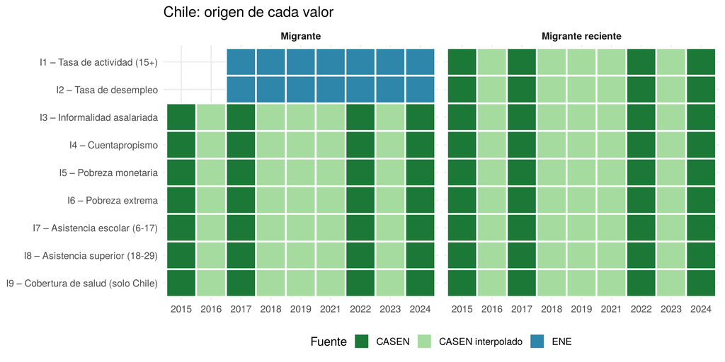

```r
bind_rows(
  brechas_ene %>% filter(pais == "Chile", !is.na(brecha_nat_mig)) %>% mutate(grupo = "Migrante"),
  brechas_sc  %>% filter(pais == "Chile", !is.na(brecha_nat_rec)) %>% mutate(grupo = "Migrante reciente")) %>%
  filter(indicador %in% clasif$indicador, anio != 2020) %>%
  mutate(indicador = ind_es[indicador],
         fuente = recode(fuente, CASEN_interpolado = "CASEN interpolado")) %>%
  ggplot(aes(factor(anio), fct_rev(indicador), fill = fuente)) +
  geom_tile(colour = "white", linewidth = 0.8) +
  facet_wrap(~ grupo) +
  scale_fill_manual(values = c("CASEN" = "#1B7837", "CASEN interpolado" = "#A6DBA0", "ENE" = "#2E86AB")) +
  labs(x = NULL, y = NULL, fill = "Fuente", title = "Chile: origen de cada valor") + tema
```

## 2.3 Poblaciones comparadas

- **Población migrante.** En Argentina, personas nacidas en otro país (EPH, CH15), lo que incluye a las naturalizadas. En Chile, personas de nacionalidad extranjera (CASEN, r1a), lo que excluye a quienes tienen doble nacionalidad con la chilena. Esta diferencia responde a la información disponible en cada encuesta.
- **Población migrante reciente.** Personas migrantes que vivían en otro país cinco años antes de la encuesta (EPH, CH16; CASEN 2015, 2017 y 2022, r2). En la CASEN 2024, que no incluye esa pregunta, las que llegaron al país entre 2020 y 2024 (r1cp).
- **Población no migrante.** El resto de la población.

Ninguna de las dos encuestas releva la situación documentaria. El tamaño de las muestras tampoco permite estimaciones anuales robustas por país de origen.

## 2.4 Indicadores y valencias

Cada indicador tiene una **valencia**: positiva si valores más altos representan un mejor acceso a derechos y negativa si representan un déficit. La valencia define el signo con que entra la brecha.

```r
tribble(
  ~Indicador, ~Dimensión, ~Valencia, ~Cálculo, ~`Argentina (EPH)`, ~`Chile`,
  "I1 – Tasa de actividad", "Laboral", "Positiva",
    "Población económicamente activa de 15 años y más / población de 15 años y más × 100",
    "ESTADO", "Total: ENE. Reciente: CASEN (activ)",
  "I2 – Tasa de desempleo", "Laboral", "Negativa",
    "Desocupados / población económicamente activa × 100 (15+)",
    "ESTADO", "Total: ENE. Reciente: CASEN (activ)",
  "I3 – Informalidad asalariada", "Laboral", "Negativa",
    "Asalariados sin aportes previsionales / total de asalariados × 100 (15+)",
    "PP07H: no le descuentan jubilación", "CASEN: no cotiza (o29/o32), incluidos los no afiliados (o28/o31)",
  "I4 – Cuentapropismo", "Laboral", "Negativa",
    "Trabajadores por cuenta propia / total de ocupados × 100 (15+)",
    "CAT_OCUP", "CASEN (o15, todos los ocupados)",
  "I5 – Pobreza por ingresos", "Pobreza", "Negativa",
    "Personas en hogares con ingreso per cápita por debajo de la línea de pobreza × 100",
    "Canastas regionales del INDEC (librería eph), ponderador PONDIH", "CASEN (2024 con la metodología anterior)",
  "I6 – Pobreza extrema", "Pobreza", "Negativa",
    "Personas por debajo de la línea de indigencia × 100",
    "Ídem, ponderador PONDIH", "CASEN (2024 con la metodología anterior)",
  "I7 – Asistencia escolar", "Social", "Positiva",
    "Personas de 6 a 17 años que asisten a un establecimiento educativo × 100",
    "CH10", "CASEN (asiste)",
  "I8 – Asistencia a educación superior", "Social", "Positiva",
    "Personas de 18 a 29 años que asisten a educación superior × 100",
    "CH10 y CH12", "CASEN (asiste y nivel)",
  "I9 – Cobertura de salud", "Social", "Positiva",
    "Personas afiliadas a algún sistema de salud (FONASA, ISAPRE, FF.AA. u otro) × 100",
    "No se construye", "CASEN (s12/s13)"
) %>% tabla("Tabla A1. Indicadores construidos, interpretación y forma de cálculo", align = "l")
```

Tabla A1. Indicadores construidos, interpretación y forma de cálculo

| Indicador | Dimensión | Valencia | Cálculo | Argentina (EPH) | Chile |
| --- | --- | --- | --- | --- | --- |
| I1 – Tasa de actividad | Laboral | Positiva | Población económicamente activa de 15 años y más / población de 15 años y más × 100 | ESTADO | Total: ENE. Reciente: CASEN (activ) |
| I2 – Tasa de desempleo | Laboral | Negativa | Desocupados / población económicamente activa × 100 (15+) | ESTADO | Total: ENE. Reciente: CASEN (activ) |
| I3 – Informalidad asalariada | Laboral | Negativa | Asalariados sin aportes previsionales / total de asalariados × 100 (15+) | PP07H: no le descuentan jubilación | CASEN: no cotiza (o29/o32), incluidos los no afiliados (o28/o31) |
| I4 – Cuentapropismo | Laboral | Negativa | Trabajadores por cuenta propia / total de ocupados × 100 (15+) | CAT_OCUP | CASEN (o15, todos los ocupados) |
| I5 – Pobreza por ingresos | Pobreza | Negativa | Personas en hogares con ingreso per cápita por debajo de la línea de pobreza × 100 | Canastas regionales del INDEC (librería eph), ponderador PONDIH | CASEN (2024 con la metodología anterior) |
| I6 – Pobreza extrema | Pobreza | Negativa | Personas por debajo de la línea de indigencia × 100 | Ídem, ponderador PONDIH | CASEN (2024 con la metodología anterior) |
| I7 – Asistencia escolar | Social | Positiva | Personas de 6 a 17 años que asisten a un establecimiento educativo × 100 | CH10 | CASEN (asiste) |
| I8 – Asistencia a educación superior | Social | Positiva | Personas de 18 a 29 años que asisten a educación superior × 100 | CH10 y CH12 | CASEN (asiste y nivel) |
| I9 – Cobertura de salud | Social | Positiva | Personas afiliadas a algún sistema de salud (FONASA, ISAPRE, FF.AA. u otro) × 100 | No se construye | CASEN (s12/s13) |

**Justificación de las valencias menos evidentes**

- **Tasa de actividad (positiva).** Una mayor participación expresa un mayor ejercicio del derecho al trabajo. Como la tasa depende de la estructura etaria, se calcula sobre la población de 15 años y más en ambos países y se controla con una versión estandarizada por edad (sección de composición y robustez).
- **Cuentapropismo (negativa).** El trabajo por cuenta propia se asocia con formas de empleo informal, precario o de plataformas que afectan de manera desproporcionada a la población migrante, y puede reflejar estrategias de inserción condicionadas por restricciones de acceso al empleo formal (Longo et al., 2023).
- **Informalidad.** Se calculó inicialmente un indicador de informalidad total, pero su inclusión junto con la informalidad asalariada y el cuentapropismo introducía una redundancia estructural. Se conservan los dos componentes desagregados.
- **Salud.** El indicador identifica a las personas sin ninguna cobertura. En Chile, la afiliación a un sistema de salud es la vía de acceso a la red de prestaciones, y su ausencia expresa exclusión. En Argentina, durante el período, la cobertura del sistema público fue universal, no requería afiliación y no dependía de la situación migratoria ni laboral (Ley 25.871, art. 8), por lo que la brecha de cobertura es, en el plano formal, nula; la EPH, además, no permite observar exclusión de hecho. Por eso el indicador no se construye para Argentina, y la sección de robustez muestra qué ocurre si se lo incluye con brecha igual a cero (S4). Hacia el final del período esto empezó a cambiar: en 2024 Salta, Mendoza, Jujuy y Santa Cruz comenzaron a cobrar la atención a personas extranjeras no residentes, y el DNU 366/2025 condicionó el acceso de quienes no son residentes permanentes, salvo emergencias, al pago previo o a un seguro de salud.

Las dos valencias discutibles (actividad y cuentapropismo) se someten a prueba en la sección de robustez.

```r
tribble(
  ~Indicador, ~`Brecha positiva significa`, ~`Brecha negativa significa`,
  "I1 – Actividad", "La población migrante participa menos", "La población migrante participa más",
  "I2 – Desempleo", "La población migrante tiene más desempleo", "La población migrante tiene menos desempleo",
  "I3 – Informalidad asalariada", "La población migrante es más informal", "La población migrante es menos informal",
  "I4 – Cuentapropismo", "La población migrante es más cuentapropista", "La población migrante es menos cuentapropista",
  "I5-I6 – Pobreza", "La población migrante es más pobre", "La población migrante es menos pobre",
  "I7-I8 – Asistencia educativa", "La población migrante asiste menos", "La población migrante asiste más",
  "I9 – Cobertura de salud", "La población migrante tiene menos cobertura", "La población migrante tiene más cobertura"
) %>% tabla("Cómo leer el signo de la brecha en cada indicador", align = "l")
```

Cómo leer el signo de la brecha en cada indicador

| Indicador | Brecha positiva significa | Brecha negativa significa |
| --- | --- | --- |
| I1 – Actividad | La población migrante participa menos | La población migrante participa más |
| I2 – Desempleo | La población migrante tiene más desempleo | La población migrante tiene menos desempleo |
| I3 – Informalidad asalariada | La población migrante es más informal | La población migrante es menos informal |
| I4 – Cuentapropismo | La población migrante es más cuentapropista | La población migrante es menos cuentapropista |
| I5-I6 – Pobreza | La población migrante es más pobre | La población migrante es menos pobre |
| I7-I8 – Asistencia educativa | La población migrante asiste menos | La población migrante asiste más |
| I9 – Cobertura de salud | La población migrante tiene menos cobertura | La población migrante tiene más cobertura |

## 2.5 Brecha armonizada

Sea $X_{i,c,t}^{g}$ el valor del indicador $i$ en el país $c$, el año $t$ y el grupo $g$ (no migrante, $nm$, o migrante, $m$). Con un factor de orientación $s_i$ igual a $+1$ para los indicadores de valencia positiva y $-1$ para los de valencia negativa, la brecha armonizada es

$$\Delta_{i,c,t} = s_i \cdot
\left(X_{i,c,t}^{nm} - X_{i,c,t}^{m}\right)$$

Un valor positivo indica ventaja relativa de la población no migrante y uno negativo, de la población migrante. La brecha se calcula por separado para la población migrante total y para la reciente.

## 2.6 Estandarización: por qué la referencia es la paridad

Los indicadores tienen niveles y variabilidades muy distintos (el desempleo ronda el 8% y la actividad el 60%), por lo que una misma brecha en puntos porcentuales no tiene el mismo significado en todos ellos. Para hacerlas comparables, cada brecha se divide por la **dispersión individual** del indicador:

$$Z_{i,c,t} =
\frac{\Delta_{i,c,t}}{\sqrt{\bar p_{i,c,t}\,(1-\bar p_{i,c,t})}}, \qquad
\bar p_{i,c,t} = \frac{X_{i,c,t}^{nm} + X_{i,c,t}^{m}}{200}$$

donde $\sqrt{\bar p(1-\bar p)}$ es el desvío estándar de una variable dicotómica con la prevalencia promedio de los dos grupos. El resultado es una diferencia de proporciones estandarizada, equivalente a la d de Cohen para proporciones (Cohen, 1988). En el artículo y en este documento se la denota $Z$, y sus valores se expresan en unidades d.

En la construcción de índices compuestos es habitual normalizar los indicadores como puntajes z, restando la media de los casos comparados y dividiendo por su desvío (OECD & JRC, 2008). Aquí no se hace así porque el ISDM no busca ordenar países entre sí, sino medir la distancia entre dos grupos respecto de una referencia sustantiva, la **igualdad en el acceso a derechos**. Restar la media de las brechas tendría tres consecuencias indeseadas.

1. **El cero dejaría de ser la paridad.** Pasaría a representar «la brecha promedio de los casos comparados», de modo que un valor cercano a cero podría corresponder a una desigualdad considerable si ambos países la comparten.
2. **Con dos países, los resultados quedarían en espejo.** Lo que uno se aleja del promedio, el otro se aleja en sentido contrario, y uno de los dos aparecería siempre en situación favorable aunque en ambos la población migrante estuviera en desventaja.
3. **El índice dependería de la muestra de casos.** Cambiaría al agregar o quitar países o años, y sería inestable en indicadores observados en pocos casos, como la cobertura de salud, que solo existe para Chile.

La dispersión individual, en cambio, conserva el cero como paridad, se calcula dentro de cada país y año sin depender de los demás casos y pondera la brecha según el nivel del indicador. Por ejemplo, una brecha de 5 pp pesa más cuando la tasa ronda el 10% que cuando ronda el 50%. La sección de robustez muestra que la comparación entre países se mantiene si se usan directamente los puntos porcentuales.

## 2.7 Agregación jerárquica

En un primer nivel, las brechas estandarizadas de cada dimensión se promedian en un **subíndice**:

$$SI_{D,c,t} = \frac{1}{n_D}\sum_{i \in D}
Z_{i,c,t}$$

En un segundo nivel, el ISDM es el promedio simple de los tres subíndices (laboral, pobreza y social), de modo que cada dimensión aporta un tercio del índice con independencia de cuántos indicadores contiene. Esto evita que la dimensión laboral, con cuatro indicadores, pese más que las otras, y permite incluir indicadores correlacionados, como pobreza y pobreza extrema, sin distorsionar el peso de su dimensión. Se calculan dos versiones.

$$ISDM^{dir}_{c,t} = \frac{1}{3}\sum_{D}
\frac{1}{n_D}\sum_{i \in D} Z_{i,c,t} \qquad\qquad ISDM^{abs}_{c,t} =
\frac{1}{3}\sum_{D} \frac{1}{n_D}\sum_{i \in D}
\left|Z_{i,c,t}\right|$$

El **direccional** conserva el signo e indica hacia qué grupo se inclina la desigualdad. El **absoluto** promedia el valor absoluto y mide su magnitud, sin que las brechas de signo contrario se compensen. Ambos se expresan también en puntos porcentuales, aplicando la misma agregación a las brechas sin estandarizar. El valor del período es el promedio de los valores anuales (sin 2020), y el índice se calcula por separado para la población migrante total y para la reciente.

## 2.8 Calidad de las estimaciones

Para cada indicador, país, año y grupo se calcula el tamaño muestral y el **tamaño efectivo de Kish** (Kish, 1965), $n_{ef} = (\sum w)^2 / \sum w^2$, que descuenta la pérdida de precisión por la variabilidad de los ponderadores. Se clasifica como OK si $n \ge 100$ y $n_{ef} \ge 50$, como CUIDADO si $n \ge 30$ y $n_{ef} \ge 30$, y como NO USAR por debajo. Es un diagnóstico: ningún valor se excluye del índice principal, y la sección de robustez muestra qué pasa si se excluyen.

## 2.9 Limitaciones

- Las encuestas no relevan la situación documentaria y subrepresentan situaciones de irregularidad extrema.
- La población migrante se define por nacimiento en Argentina y por nacionalidad en Chile.
- En Chile, la mayor parte de los valores anuales son interpolados entre ondas de la CASEN, y la serie de la población migrante total combina la ENE con la CASEN. Las variaciones anuales deben leerse como tendencias.
- En Chile, en 2015 y 2016 la dimensión laboral de la población migrante total tiene solo dos indicadores (la ENE comienza en 2017).
- Algunas estimaciones de la población migrante reciente en Argentina se basan en muestras reducidas.
- Los indicadores de ingresos dependen de ingresos declarados.

# 3 Contexto

```r
contexto <- c("Gráfico 1. Stock migratorio de Argentina y Chile 1960-2024 (miles de personas)" = "output/contexto/stock_migratorio_arg_chl.png",
              "Gráfico A1. PIB per cápita Argentina y Chile (1995-2022)" = "output/contexto/gdp_per_capita_arg_chl_media.png",
              "Gráfico A2. Coeficiente de Gini Argentina y Chile (1995-2022)" = "output/contexto/gini_arg_chl_media.png")
for (i in seq_along(contexto)) {
  if (file.exists(contexto[i])) {
    cat("\n\n**", names(contexto)[i], "**\n\n", sep = "")
    cat(sprintf("![](%s){width=85%%}\n\n", contexto[i]))
  }
}
```

**Gráfico 1. Stock migratorio de Argentina y Chile 1960-2024 (miles de personas)**

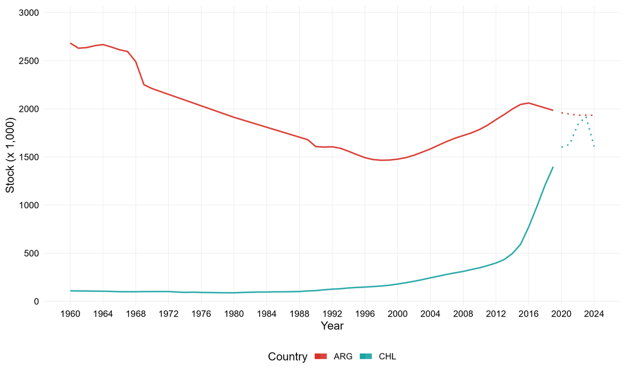

**Gráfico A1. PIB per cápita Argentina y Chile (1995-2022)**

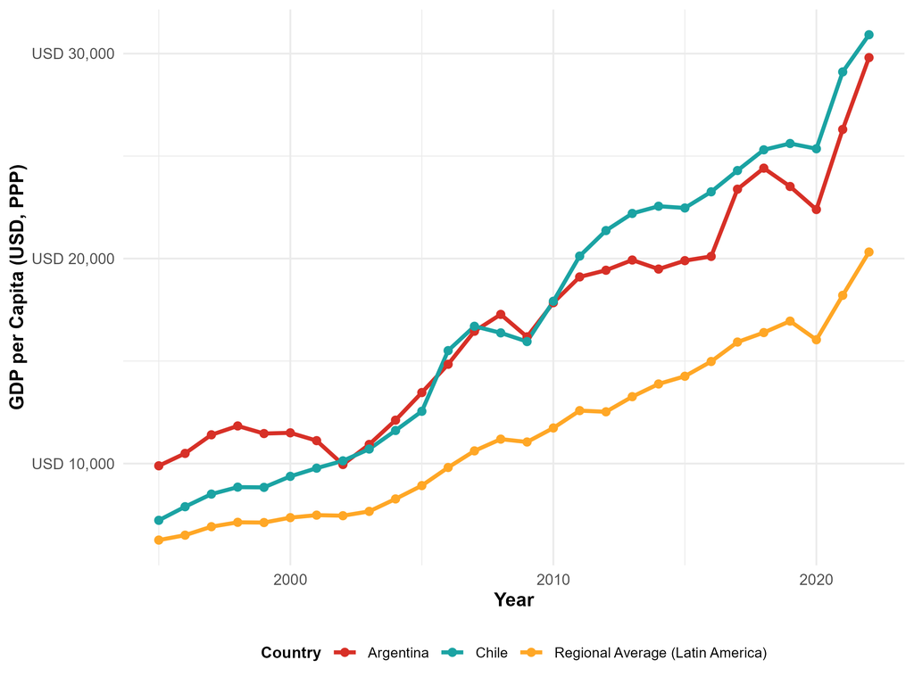

**Gráfico A2. Coeficiente de Gini Argentina y Chile (1995-2022)**

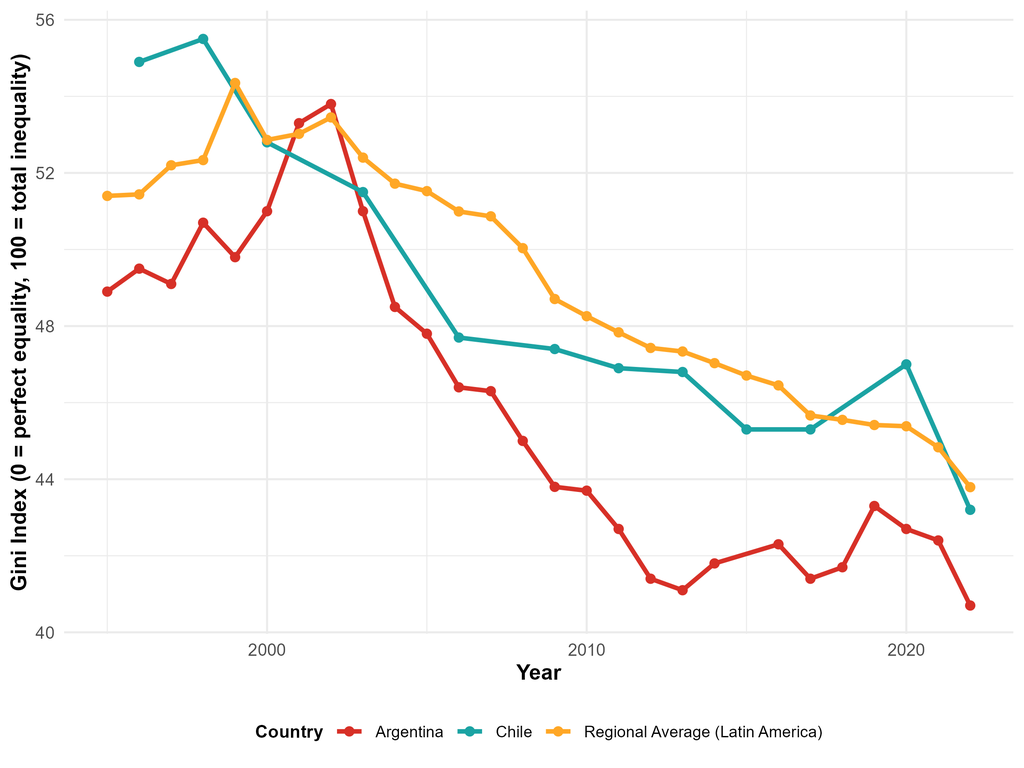

# 4 Indicadores por país, año y grupo

Tasas (%) de cada grupo. Los puntos marcan valores observados; en Chile, los tramos sin punto son interpolados.

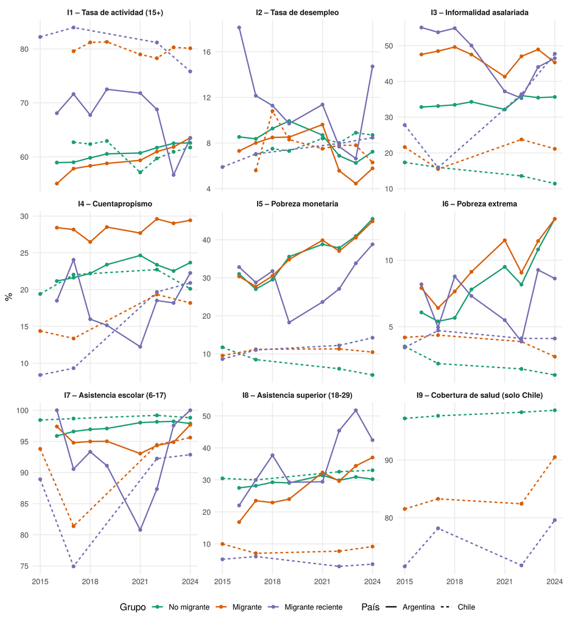

```r
ind_largo <- bind_rows(
  brechas_ene %>% transmute(pais, fuente, anio, indicador, `No migrante` = nativos, Migrante = migrantes),
  brechas_sc  %>% transmute(pais, fuente, anio, indicador, `Migrante reciente` = migrantes_recientes)) %>%
  pivot_longer(c(`No migrante`, Migrante, `Migrante reciente`), names_to = "grupo", values_to = "tasa") %>%
  filter(!is.na(tasa), anio != 2020, indicador %in% clasif$indicador) %>%
  distinct(pais, anio, indicador, grupo, .keep_all = TRUE) %>%
  mutate(indicador = factor(ind_es[indicador], levels = ind_es[clasif$indicador]),
         grupo = factor(grupo, levels = names(colores_grupo)),
         observado = fuente != "CASEN_interpolado")

ggplot(ind_largo, aes(anio, tasa, colour = grupo, linetype = pais)) +
  geom_line(linewidth = 0.8) +
  geom_point(data = filter(ind_largo, observado), size = 1.6) +
  facet_wrap(~ indicador, scales = "free_y", ncol = 3) +
  scale_colour_manual(values = colores_grupo) +
  scale_x_continuous(breaks = seq(2015, 2024, 3)) +
  labs(x = NULL, y = "%", colour = "Grupo", linetype = "País") + tema
```

# 5 Brechas por dimensión

Brecha armonizada promedio del período, en puntos porcentuales y sin estandarizar (promedio 2015-2024, sin 2020). Positivo = mejor la población no migrante. Los gráficos muestran la distribución de los valores anuales.

```r
brechas_ind <- prep %>%
  group_by(dimension, indicador, pais, grupo) %>%
  summarise(b = mean(brecha_normalizada), .groups = "drop") %>%
  pivot_wider(names_from = pais, values_from = b) %>%
  mutate(`CHL−ARG` = Chile - Argentina) %>%
  pivot_wider(names_from = grupo, values_from = c(Argentina, Chile, `CHL−ARG`)) %>%
  transmute(dimension, Indicador = ind_es[indicador],
            ARG = Argentina_Migrants, CHL = Chile_Migrants, `CHL−ARG` = `CHL−ARG_Migrants`,
            `ARG ` = `Argentina_Recent migrants`, `CHL ` = `Chile_Recent migrants`,
            `CHL−ARG ` = `CHL−ARG_Recent migrants`)
titulos <- c(Labor   = "Tabla 1. Brechas laborales no migrante-migrante por país y subgrupo poblacional (pp). Argentina y Chile, 2015–2024",
             Poverty = "Tabla 2. Brechas relativas a privación económica no migrante-migrante por país y subgrupo poblacional (pp). Argentina y Chile, 2015–2024",
             Social  = "Tabla 3. Brechas relativas a derechos sociales no migrante-migrante por país y subgrupo poblacional (pp). Argentina y Chile, 2015–2024")
for (d in names(titulos)) {
  print(brechas_ind %>% filter(dimension == d) %>% select(-dimension) %>%
          tabla(titulos[d], digits = 1) %>%
          add_header_above(c(" " = 1, "Migración total" = 3, "Migración reciente" = 3)))
  cat("\n\n")
}
```

Tabla 1. Brechas laborales no migrante-migrante por país y subgrupo poblacional (pp). Argentina y Chile, 2015–2024

| Indicador | Migración total ARG | Migración total CHL | Migración total CHL−ARG | Migración reciente ARG | Migración reciente CHL | Migración reciente CHL−ARG |
| --- | --- | --- | --- | --- | --- | --- |
| I1 – Tasa de actividad (15+) | 1,3 | -18,9 | -20,2 | -6,9 | -21,9 | -15,0 |
| I2 – Tasa de desempleo | -0,9 | -0,2 | 0,7 | 3,3 | -0,9 | -4,2 |
| I3 – Informalidad asalariada | 12,8 | 5,5 | -7,4 | 13,0 | 15,1 | 2,2 |
| I4 – Cuentapropismo | 5,6 | -5,2 | -10,8 | -4,7 | -7,1 | -2,3 |

Tabla 2. Brechas relativas a privación económica no migrante-migrante por país y subgrupo poblacional (pp). Argentina y Chile, 2015–2024

| Indicador | Migración total ARG | Migración total CHL | Migración total CHL−ARG | Migración reciente ARG | Migración reciente CHL | Migración reciente CHL−ARG |
| --- | --- | --- | --- | --- | --- | --- |
| I5 – Pobreza monetaria | -0,1 | 3,3 | 3,3 | -6,4 | 4,0 | 10,4 |
| I6 – Pobreza extrema | 1,2 | 1,7 | 0,5 | -1,3 | 2,0 | 3,3 |

Tabla 3. Brechas relativas a derechos sociales no migrante-migrante por país y subgrupo poblacional (pp). Argentina y Chile, 2015–2024

| Indicador | Migración total ARG | Migración total CHL | Migración total CHL−ARG | Migración reciente ARG | Migración reciente CHL | Migración reciente CHL−ARG |
| --- | --- | --- | --- | --- | --- | --- |
| I7 – Asistencia escolar (6-17) | 2,1 | 8,8 | 6,7 | 4,8 | 13,0 | 8,2 |
| I8 – Asistencia superior (18-29) | 2,0 | 23,3 | 21,3 | -6,4 | 26,9 | 33,3 |
| I9 – Cobertura de salud (solo Chile) | — | 14,0 | — | — | 22,7 | — |

```r
grafico_dim <- function(dim, titulo) {
  cat("\n\n**", titulo, "**\n\n", sep = "")
  p <- prep %>%
    filter(dimension == dim) %>%
    mutate(indicador = fct_rev(factor(ind_es[indicador], levels = ind_es)),
           grupo = grupo_es[grupo]) %>%
    ggplot(aes(indicador, brecha_normalizada, colour = pais)) +
    geom_hline(yintercept = 0, linetype = "dashed", alpha = 0.7) +
    geom_boxplot(alpha = 0.4, position = position_dodge(0.8), outlier.shape = NA) +
    geom_point(position = position_jitterdodge(jitter.width = 0.15, dodge.width = 0.8, seed = 1),
               alpha = 0.6, size = 1.8) +
    coord_flip() + facet_wrap(~ grupo) +
    scale_colour_manual(values = colores_pais) +
    labs(x = NULL, y = "Brecha armonizada (pp)  ·  negativo = mejor migrante | positivo = mejor no migrante",
         colour = "País", caption = "Cada punto es un año. Datos sin estandarizar, normalizados según la dirección del indicador.") + tema
  print(p)
}
grafico_dim("Labor",   "Gráfico 2. Distribución anual de las brechas laborales no migrante-migrante por país y subgrupo poblacional (pp). Argentina y Chile, 2015–2024")
```

**Gráfico 2. Distribución anual de las brechas laborales no migrante-migrante por país y subgrupo poblacional (pp). Argentina y Chile, 2015–2024**

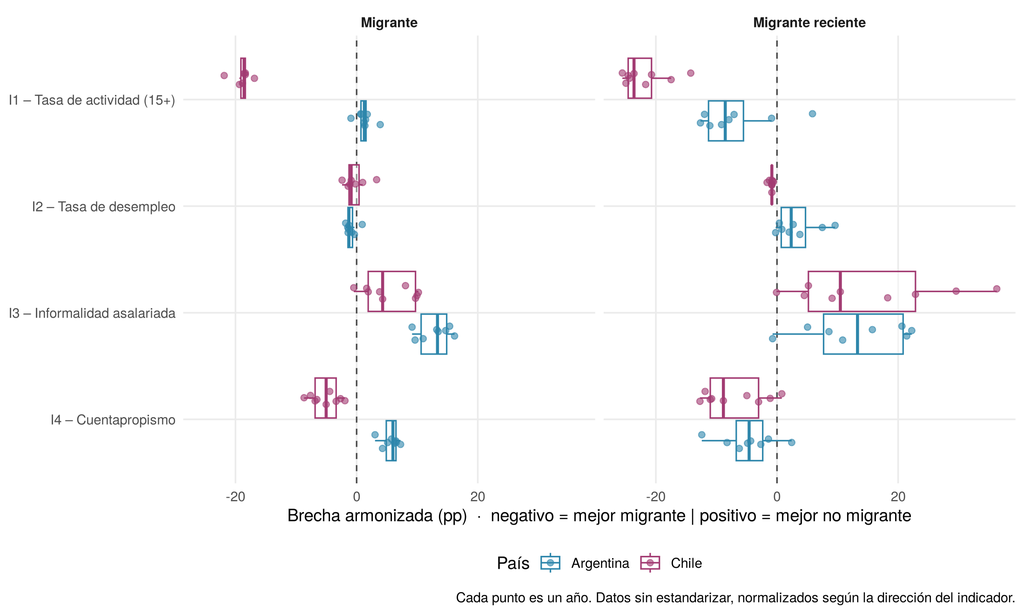

```r
grafico_dim("Poverty", "Gráfico 3. Distribución anual de las brechas relativas a privación económica no migrante-migrante por país y subgrupo poblacional (pp). Argentina y Chile, 2015–2024")
```

**Gráfico 3. Distribución anual de las brechas relativas a privación económica no migrante-migrante por país y subgrupo poblacional (pp). Argentina y Chile, 2015–2024**

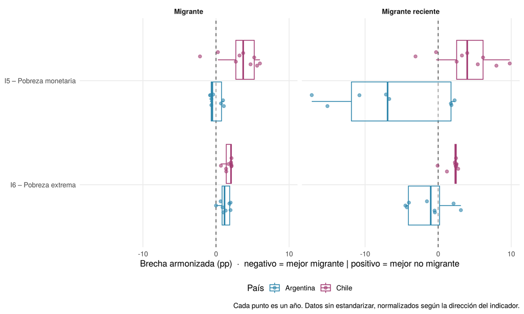

```r
grafico_dim("Social",  "Gráfico 4. Distribución anual de brechas relativas a derechos sociales no migrante-migrante por país y subgrupo poblacional (pp). Argentina y Chile, 2015–2024")
```

**Gráfico 4. Distribución anual de brechas relativas a derechos sociales no migrante-migrante por país y subgrupo poblacional (pp). Argentina y Chile, 2015–2024**

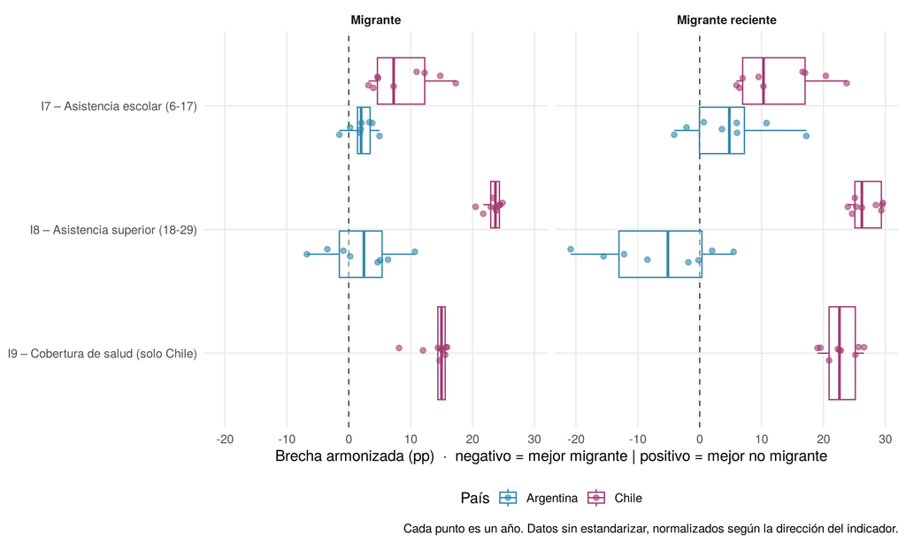

# 6 El índice

## 6.1 Cómo se calcula

El ISDM se construye en cuatro pasos, para cada país $c$, año $t$ y grupo migrante (total o reciente).

**1. Brecha armonizada (pp).** Diferencia entre la tasa de la población no migrante y la del grupo migrante, con el signo de la valencia ($s_i = +1$ si más es mejor, $-1$ si más es peor):

$$\Delta_{i,c,t} = s_i \cdot
\left(X_{i,c,t}^{nm} - X_{i,c,t}^{m}\right)$$

**2. Brecha estandarizada (Z, en unidades d).** La brecha se divide por la dispersión individual del indicador, calculada con la tasa promedio de los dos grupos:

$$Z_{i,c,t} =
\frac{\Delta_{i,c,t}}{\sqrt{\bar p_{i,c,t}\,(1-\bar p_{i,c,t})}}, \qquad
\bar p_{i,c,t} = \frac{X_{i,c,t}^{nm} + X_{i,c,t}^{m}}{200}$$

**3. Subíndices por dimensión.** Promedio de las brechas estandarizadas de los indicadores de cada dimensión $D$ (laboral, pobreza, social), con signo para el direccional y en valor absoluto para el absoluto:

$$SI^{dir}_{D,c,t} = \frac{1}{n_D}\sum_{i
\in D} Z_{i,c,t} \qquad\qquad SI^{abs}_{D,c,t} = \frac{1}{n_D}\sum_{i
\in D} \left|Z_{i,c,t}\right|$$

**4. ISDM.** Promedio simple de los tres subíndices, de modo que cada dimensión pesa un tercio:

$$ISDM^{dir}_{c,t} = \frac{1}{3}\sum_{D}
SI^{dir}_{D,c,t} \qquad\qquad ISDM^{abs}_{c,t} = \frac{1}{3}\sum_{D}
SI^{abs}_{D,c,t}$$

El valor del período es el promedio de los valores anuales, sin 2020. Las versiones en puntos porcentuales aplican los pasos 3 y 4 a $\Delta$ en lugar de $Z$.

**Cómo leer los valores.** El ISDM absoluto vale 0 cuando hay paridad en todos los indicadores y crece con la distancia entre grupos, sin importar quién está mejor. Como referencia, en unidades d, alrededor de 0,2 es una diferencia pequeña y alrededor de 0,5, moderada (Cohen, 1988). El ISDM direccional es positivo cuando, en promedio, la población no migrante está mejor y negativo cuando lo está la migrante. Como las brechas de distinto signo se compensan, el direccional es siempre menor o igual que el absoluto en valor absoluto; la distancia entre ambos indica cuánto se compensan ventajas y desventajas entre indicadores.

### 6.1.1 Ejemplo completo: Chile, 2022, población migrante total

```r
ej_pais <- "Chile"; ej_anio <- 2022; ej_grupo <- "Migrants"
ej <- prep %>% filter(pais == ej_pais, anio == ej_anio, grupo == ej_grupo) %>%
  mutate(dimension = factor(dimension, levels = names(dim_es))) %>%
  arrange(dimension, indicador)
ej %>%
  transmute(Dimensión = dim_es[as.character(dimension)], Indicador = ind_es[indicador],
            Valencia = if_else(tipo == "positivo", "+1", "−1"),
            `No migrante (%)` = tasa_no_migrante, `Migrante (%)` = tasa_grupo,
            `Δ (pp)` = brecha_normalizada, `p̄` = p_media,
            `√(p̄(1−p̄)) (pp)` = disp_ind, `Z (d)` = brecha_z) %>%
  tabla(sprintf("Paso 1 y 2. Brechas de %s en %d, población migrante total", ej_pais, ej_anio), digits = 3)
```

Paso 1 y 2. Brechas de Chile en 2022, población migrante total

[output not shown]

Por ejemplo, en informalidad asalariada la valencia es negativa, de modo que la brecha armonizada es $\Delta = -1 \cdot (13{,}56 - 23{,}76) = 10{,}20$ pp. La tasa promedio de ambos grupos es $\bar p = (13{,}56 + 23{,}76)/200 = 0{,}187$, y la dispersión, $\sqrt{0{,}187 \cdot (1 - 0{,}187)} = 0{,}390$, es decir, 39,0 pp. Entonces $Z = 10{,}20 / 39{,}0 = 0{,}262$: la población migrante está en desventaja, con una diferencia pequeña a moderada. En la tasa de actividad, en cambio, la población migrante participa más, por lo que la brecha es negativa (ventaja migrante).

```r
ej_sub <- ej %>% group_by(dimension) %>%
  summarise(n = n(), `SI direccional (d)` = mean(brecha_z), `SI absoluto (d)` = mean(abs(brecha_z)),
            `SI direccional (pp)` = mean(brecha_normalizada), `SI absoluto (pp)` = mean(abs(brecha_normalizada)),
            .groups = "drop") %>%
  mutate(dimension = dim_es[as.character(dimension)])
ej_isdm <- ej_sub %>% summarise(dimension = "ISDM (promedio de los tres subíndices)", n = sum(n),
                                across(starts_with("SI"), mean))
bind_rows(ej_sub, ej_isdm) %>%
  rename(Dimensión = dimension, Indicadores = n) %>%
  tabla(sprintf("Pasos 3 y 4. Subíndices e ISDM de %s en %d, población migrante total", ej_pais, ej_anio), digits = 3) %>%
  row_spec(nrow(ej_sub) + 1, bold = TRUE)
```

Pasos 3 y 4. Subíndices e ISDM de Chile en 2022, población migrante total

| Dimensión | Indicadores | SI direccional (d) | SI absoluto (d) | SI direccional (pp) | SI absoluto (pp) |
| --- | --- | --- | --- | --- | --- |
| Laboral | 4 | -0,057 | 0,188 | -2,987 | 8,088 |
| Pobreza | 2 | 0,154 | 0,154 | 3,643 | 3,643 |
| Social | 3 | 0,476 | 0,476 | 15,149 | 15,149 |
| ISDM (promedio de los tres subíndices) | 9 | 0,191 | 0,273 | 5,268 | 8,960 |

```r
ej_ctrl <- res$anual %>% filter(pais == ej_pais, anio == ej_anio, grupo == ej_grupo)
```

El resultado coincide con el ISDM anual guardado por la cadena (absoluto 0,273 y direccional 0,191 en unidades d). Repetido para cada año y promediado, se obtiene el valor del período de la Tabla 4.

## 6.2 Promedio del período

```r
res$resumen %>%
  transmute(País = pais, Grupo = grupo_es[grupo],
            `Absoluto (d)` = isdm_abs_de, `Direccional (d)` = isdm_dir_de,
            `Absoluto (pp)` = isdm_abs_pp, `Direccional (pp)` = isdm_dir_pp, Años = n_anios) %>%
  tabla("Tabla 4. Índice Sintético de Desigualdad Migratoria (ISDM) por país y subgrupo poblacional. Argentina y Chile, promedio 2015–2024 (sin 2020)", digits = 3)
```

Tabla 4. Índice Sintético de Desigualdad Migratoria (ISDM) por país y subgrupo poblacional. Argentina y Chile, promedio 2015–2024 (sin 2020)

| País | Grupo | Absoluto (d) | Direccional (d) | Absoluto (pp) | Direccional (pp) | Años |
| --- | --- | --- | --- | --- | --- | --- |
| Argentina | Migrante | 0,088 | 0,065 | 3,285 | 2,432 | 8 |
| Argentina | Migrante reciente | 0,176 | -0,019 | 6,690 | -1,166 | 8 |
| Chile | Migrante | 0,257 | 0,168 | 8,426 | 4,683 | 9 |
| Chile | Migrante reciente | 0,340 | 0,217 | 11,853 | 6,726 | 9 |

## 6.3 Evolución anual

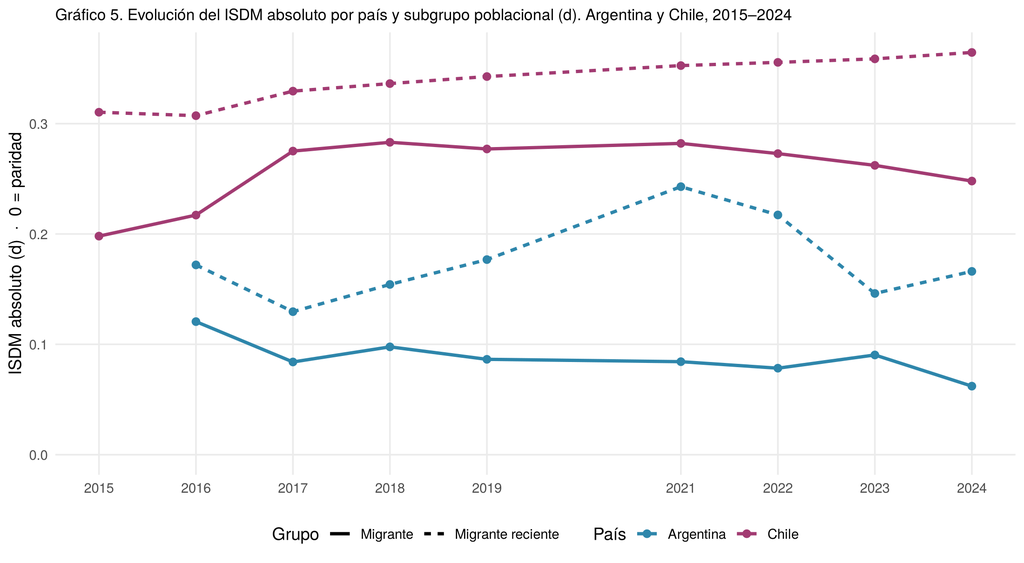

```r
anual <- res$anual %>% mutate(grupo = grupo_es[grupo])
ggplot(anual, aes(anio, isdm_abs_de, colour = pais, linetype = grupo)) +
  geom_line(linewidth = 1.1) + geom_point(size = 2.2) +
  scale_colour_manual(values = colores_pais) +
  scale_x_continuous(breaks = sort(unique(anual$anio))) +
  scale_y_continuous(limits = c(0, NA)) +
  labs(x = NULL, y = "ISDM absoluto (d)  ·  0 = paridad", colour = "País", linetype = "Grupo",
       title = "Gráfico 5. Evolución del ISDM absoluto por país y subgrupo poblacional (d). Argentina y Chile, 2015–2024") + tema +
  theme(plot.title = element_text(size = 11))
```

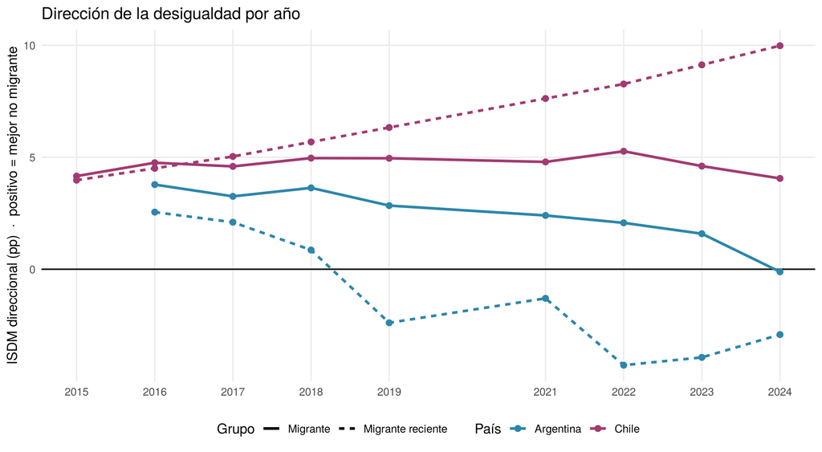

```r
ggplot(anual, aes(anio, isdm_dir_pp, colour = pais, linetype = grupo)) +
  geom_hline(yintercept = 0, linewidth = 0.6) +
  geom_line(linewidth = 1.1) + geom_point(size = 2.2) +
  scale_colour_manual(values = colores_pais) +
  scale_x_continuous(breaks = sort(unique(anual$anio))) +
  labs(x = NULL, y = "ISDM direccional (pp)  ·  positivo = mejor no migrante",
       colour = "País", linetype = "Grupo", title = "Dirección de la desigualdad por año") + tema
```

```r
anual %>%
  arrange(anio) %>%
  select(pais, grupo, anio, isdm_abs_de) %>%
  pivot_wider(names_from = anio, values_from = isdm_abs_de) %>%
  rename(País = pais, Grupo = grupo) %>%
  arrange(País, Grupo) %>%
  tabla("ISDM absoluto (d) por año", digits = 3)
```

ISDM absoluto (d) por año

| País | Grupo | 2015 | 2016 | 2017 | 2018 | 2019 | 2021 | 2022 | 2023 | 2024 |
| --- | --- | --- | --- | --- | --- | --- | --- | --- | --- | --- |
| Argentina | Migrante | — | 0,121 | 0,084 | 0,098 | 0,086 | 0,084 | 0,078 | 0,090 | 0,062 |
| Argentina | Migrante reciente | — | 0,172 | 0,130 | 0,154 | 0,177 | 0,243 | 0,217 | 0,146 | 0,166 |
| Chile | Migrante | 0,198 | 0,217 | 0,275 | 0,283 | 0,277 | 0,282 | 0,273 | 0,262 | 0,248 |
| Chile | Migrante reciente | 0,310 | 0,307 | 0,329 | 0,336 | 0,343 | 0,353 | 0,356 | 0,359 | 0,365 |

En todos los años con información para ambos países, el ISDM absoluto de Chile supera al de Argentina, tanto para la migración total como para la reciente: 16 de 16 comparaciones (cada año, para cada grupo).

## 6.4 Subíndices por dimensión

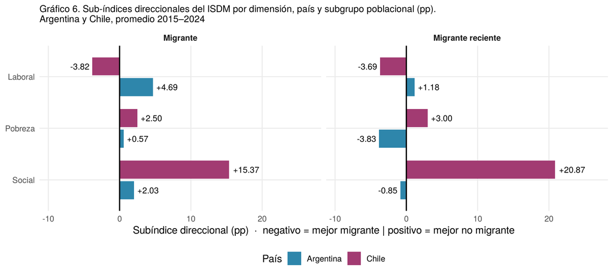

```r
sub <- res$subindices_resumen %>%
  mutate(dimension = factor(dim_es[dimension], levels = dim_es), grupo = grupo_es[grupo])
ggplot(sub, aes(sub_dir_pp, fct_rev(dimension), fill = pais)) +
  geom_col(position = position_dodge(0.8), width = 0.7) +
  geom_vline(xintercept = 0, linewidth = 0.7) +
  geom_text(aes(label = sprintf("%+.2f", sub_dir_pp), hjust = if_else(sub_dir_pp >= 0, -0.15, 1.15)),
            position = position_dodge(0.8), size = 3.5) +
  facet_wrap(~ grupo) +
  scale_fill_manual(values = colores_pais) +
  scale_x_continuous(expand = expansion(mult = 0.3)) +
  labs(x = "Subíndice direccional (pp)  ·  negativo = mejor migrante | positivo = mejor no migrante",
       y = NULL, fill = "País",
       title = "Gráfico 6. Sub-índices direccionales del ISDM por dimensión, país y subgrupo poblacional (pp).\nArgentina y Chile, promedio 2015–2024") + tema +
  theme(plot.title = element_text(size = 11))
```

```r
sub %>%
  transmute(País = pais, Grupo = grupo, Dimensión = dimension,
            `Absoluto (d)` = sub_abs_de, `Direccional (d)` = sub_dir_de,
            `Absoluto (pp)` = sub_abs_pp, `Direccional (pp)` = sub_dir_pp) %>%
  arrange(Grupo, Dimensión, País) %>%
  tabla("Subíndices por dimensión", digits = 3)
```

Subíndices por dimensión

| País | Grupo | Dimensión | Absoluto (d) | Direccional (d) | Absoluto (pp) | Direccional (pp) |
| --- | --- | --- | --- | --- | --- | --- |
| Argentina | Migrante | Laboral | 0,116 | 0,095 | 5,272 | 4,691 |
| Chile | Migrante | Laboral | 0,175 | -0,085 | 7,162 | -3,822 |
| Argentina | Migrante | Pobreza | 0,030 | 0,022 | 0,975 | 0,574 |
| Chile | Migrante | Pobreza | 0,118 | 0,110 | 2,741 | 2,497 |
| Argentina | Migrante | Social | 0,117 | 0,077 | 3,608 | 2,029 |
| Chile | Migrante | Social | 0,480 | 0,480 | 15,374 | 15,374 |
| Argentina | Migrante reciente | Laboral | 0,170 | 0,026 | 7,543 | 1,177 |
| Chile | Migrante reciente | Laboral | 0,266 | -0,090 | 11,304 | -3,692 |
| Argentina | Migrante reciente | Pobreza | 0,133 | -0,092 | 5,208 | -3,828 |
| Chile | Migrante reciente | Pobreza | 0,140 | 0,127 | 3,388 | 3,004 |
| Argentina | Migrante reciente | Social | 0,224 | 0,009 | 7,318 | -0,845 |
| Chile | Migrante reciente | Social | 0,614 | 0,614 | 20,868 | 20,868 |

# 7 Robustez

Cada prueba cambia una decisión metodológica y recalcula el índice. La pregunta central es si se mantiene el resultado principal, es decir, que **la magnitud de la desigualdad (ISDM absoluto) es mayor en Chile que en Argentina**, para la migración total y para la reciente. Al final de la sección, una tabla resume todas las pruebas.

```r
resumir <- function(r, prueba, familia) {
  r$resumen %>% transmute(familia, prueba, pais, grupo,
                          abs_d = isdm_abs_de, dir_pp = isdm_dir_pp, abs_pp = isdm_abs_pp)
}
ancho <- function(df, var) {
  df %>% select(familia, prueba, pais, grupo, v = {{ var }}) %>%
    mutate(col = paste(if_else(pais == "Argentina", "ARG", "CHL"),
                       if_else(grupo == "Migrants", "total", "reciente"))) %>%
    select(-pais, -grupo) %>%
    pivot_wider(names_from = col, values_from = v) %>%
    select(familia, prueba, `ARG total`, `CHL total`, `ARG reciente`, `CHL reciente`)
}
principal <- resumir(res, "Especificación principal", "Principal")
```

## 7.1 Valencias

El ISDM absoluto no depende de las valencias. Cambiar la valencia de un indicador solo cambia el signo de su brecha, y el absoluto toma el valor absoluto, por lo que su magnitud es idéntica. Las valencias solo afectan al ISDM direccional y a los subíndices direccionales. Las dos valencias discutibles son la de la tasa de actividad y la del cuentapropismo. Se prueba invertir cada una y excluir cada indicador.

```r
cambiar <- function(cl, ind, tipo_nuevo) cl %>% mutate(tipo = if_else(indicador == ind, tipo_nuevo, tipo))
val <- list(
  "Cuentapropismo con valencia positiva" = cambiar(clasif, "I4_cuentapropismo", "positivo"),
  "Sin cuentapropismo"                   = filter(clasif, indicador != "I4_cuentapropismo"),
  "Actividad con valencia negativa"      = cambiar(clasif, "I1_tasa_actividad", "negativo"),
  "Sin tasa de actividad"                = filter(clasif, indicador != "I1_tasa_actividad"),
  "Sin actividad ni cuentapropismo"      = filter(clasif, !indicador %in% c("I1_tasa_actividad", "I4_cuentapropismo"))
)
rob_val <- imap_dfr(val, ~ resumir(isdm_con(datos, .x), .y, "Valencias"))
lab_val <- imap_dfr(c(list("Especificación principal" = clasif), val), function(cl, nombre) {
  isdm_con(datos, cl)$subindices_resumen %>% filter(dimension == "Labor") %>%
    transmute(prueba = nombre, pais, grupo, lab = sub_dir_pp)
}) %>%
  mutate(col = paste("Laboral dir. (pp)", if_else(pais == "Argentina", "ARG", "CHL"),
                     if_else(grupo == "Migrants", "total", "reciente"))) %>%
  select(-pais, -grupo) %>% pivot_wider(names_from = col, values_from = lab) %>%
  select(prueba, ends_with("ARG total"), ends_with("CHL total"), ends_with("ARG reciente"), ends_with("CHL reciente"))

bind_rows(principal, rob_val) %>% ancho(dir_pp) %>% select(-familia) %>%
  left_join(lab_val, by = "prueba") %>%
  rename(Prueba = prueba) %>%
  tabla("ISDM direccional y subíndice laboral direccional (pp) según las valencias", digits = 2) %>%
  add_header_above(c(" " = 1, "ISDM direccional (pp)" = 4, "Subíndice laboral direccional (pp)" = 4))
```

ISDM direccional y subíndice laboral direccional (pp) según las valencias

| Prueba | ISDM direccional (pp) ARG total | ISDM direccional (pp) CHL total | ISDM direccional (pp) ARG reciente | ISDM direccional (pp) CHL reciente | Subíndice laboral direccional (pp) Laboral dir. (pp) ARG total | Subíndice laboral direccional (pp) Laboral dir. (pp) CHL total | Subíndice laboral direccional (pp) Laboral dir. (pp) ARG reciente | Subíndice laboral direccional (pp) Laboral dir. (pp) CHL reciente |
| --- | --- | --- | --- | --- | --- | --- | --- | --- |
| Especificación principal | 2,43 | 4,68 | -1,17 | 6,73 | 4,69 | -3,82 | 1,18 | -3,69 |
| Cuentapropismo con valencia positiva | 1,50 | 5,78 | -0,38 | 7,90 | 1,90 | -0,54 | 3,53 | -0,16 |
| Sin cuentapropismo | 2,33 | 5,06 | -0,51 | 7,10 | 4,39 | -2,68 | 3,14 | -2,57 |
| Actividad con valencia negativa | 2,22 | 7,13 | -0,02 | 10,38 | 4,06 | 3,52 | 4,61 | 7,26 |
| Sin tasa de actividad | 2,81 | 5,93 | -0,27 | 8,75 | 5,83 | -0,09 | 3,86 | 2,38 |
| Sin actividad ni cuentapropismo | 2,85 | 6,95 | 1,16 | 10,32 | 5,95 | 2,98 | 8,14 | 7,10 |

```r
bind_rows(principal, rob_val) %>% ancho(abs_d) %>% select(-familia) %>% rename(Prueba = prueba) %>%
  tabla("ISDM absoluto (d) según las valencias", digits = 3)
```

ISDM absoluto (d) según las valencias

| Prueba | ARG total | CHL total | ARG reciente | CHL reciente |
| --- | --- | --- | --- | --- |
| Especificación principal | 0,088 | 0,257 | 0,176 | 0,340 |
| Cuentapropismo con valencia positiva | 0,088 | 0,257 | 0,176 | 0,340 |
| Sin cuentapropismo | 0,087 | 0,260 | 0,180 | 0,347 |
| Actividad con valencia negativa | 0,088 | 0,257 | 0,176 | 0,340 |
| Sin tasa de actividad | 0,098 | 0,238 | 0,175 | 0,316 |
| Sin actividad ni cuentapropismo | 0,100 | 0,233 | 0,181 | 0,315 |

```r
dir_chile <- rob_val %>% filter(pais == "Chile") %>% pull(dir_pp)
```

Invertir una valencia deja intacto el ISDM absoluto, como se espera. Excluir la tasa de actividad o el cuentapropismo lo modifica poco y no altera el orden entre países. En la dirección, el ISDM direccional de Chile se mantiene favorable a la población no migrante en todas las variantes (entre 5,1 y 10,4 pp). La valencia de la tasa de actividad es la decisión con más peso sobre la dirección del subíndice laboral de Chile, porque la población migrante participa mucho más que la no migrante. Con valencia positiva, esa mayor participación cuenta como ventaja migrante y compensa la desventaja en informalidad; si se la considera un déficit, el subíndice laboral chileno pasa a ser desfavorable a la población migrante.

## 7.2 Indicador de salud

Se comparan cinco especificaciones. S0 mide el uso exclusivo del sistema público con valencia positiva, una operacionalización habitual del acceso a la salud. En Argentina, sin embargo, esa variable identifica a quienes no tienen obra social ni prepaga, por lo que expresa sobre todo la falta de cobertura contributiva y se superpone con la informalidad, que ya integra la dimensión laboral. S1 excluye la salud, S2 invierte la valencia de S0, S3 es la especificación principal (cobertura en Chile, sin indicador en Argentina) y S4 incorpora además el indicador en Argentina con una brecha igual a cero, que corresponde a la cobertura universal y sin afiliación del sistema público durante el período.

```r
# S4: cobertura de salud también en Argentina, con brecha nula (cobertura pública universal sin afiliación)
arg_salud <- datos %>% filter(pais == "Argentina") %>% distinct(pais, anio, grupo) %>%
  mutate(fuente = "supuesto", indicador = "I9_cobertura_salud",
         tasa_no_migrante = 99, tasa_grupo = 99, brecha = 0)   # Δ = 0 => Z = 0
r_s4 <- isdm_con(bind_rows(datos, arg_salud))
s4 <- r_s4$resumen %>%
  left_join(r_s4$subindices_resumen %>% filter(dimension == "Social") %>% select(pais, grupo, social_dir_pp = sub_dir_pp),
            by = c("pais", "grupo")) %>%
  mutate(escenario = "S4 Cobertura (Chile) y brecha nula en Argentina", .before = 1)
sensibilidad <- bind_rows(sensibilidad, s4)
sensibilidad %>%
  transmute(Escenario = escenario, País = pais, Grupo = grupo_es[grupo],
            `Absoluto (d)` = isdm_abs_de, `Direccional (pp)` = isdm_dir_pp,
            `Social direccional (pp)` = social_dir_pp) %>%
  tabla("Tabla A2. ISDM absoluto y dimensión social según la especificación del indicador de salud. Argentina y Chile, promedio 2015–2024", digits = 3)
```

Tabla A2. ISDM absoluto y dimensión social según la especificación del indicador de salud. Argentina y Chile, promedio 2015–2024

| Escenario | País | Grupo | Absoluto (d) | Direccional (pp) | Social direccional (pp) |
| --- | --- | --- | --- | --- | --- |
| S0 Uso del sistema público (valencia +) | Argentina | Migrante | 0,092 | 1,374 | -1,144 |
| S0 Uso del sistema público (valencia +) | Argentina | Migrante reciente | 0,192 | -3,122 | -6,715 |
| S0 Uso del sistema público (valencia +) | Chile | Migrante | 0,227 | 4,285 | 14,178 |
| S0 Uso del sistema público (valencia +) | Chile | Migrante reciente | 0,297 | 5,585 | 17,442 |
| S1 Sin indicador de salud | Argentina | Migrante | 0,088 | 2,432 | 2,029 |
| S1 Sin indicador de salud | Argentina | Migrante reciente | 0,176 | -1,166 | -0,845 |
| S1 Sin indicador de salud | Chile | Migrante | 0,256 | 4,905 | 16,039 |
| S1 Sin indicador de salud | Chile | Migrante reciente | 0,331 | 6,417 | 19,941 |
| S2 Uso del sistema público (valencia -) | Argentina | Migrante | 0,092 | 3,038 | 3,850 |
| S2 Uso del sistema público (valencia -) | Argentina | Migrante reciente | 0,192 | 0,979 | 5,588 |
| S2 Uso del sistema público (valencia -) | Chile | Migrante | 0,227 | 1,961 | 7,207 |
| S2 Uso del sistema público (valencia -) | Chile | Migrante reciente | 0,297 | 2,819 | 9,146 |
| S3 Cobertura (Chile), sin indicador ARG (principal) | Argentina | Migrante | 0,088 | 2,432 | 2,029 |
| S3 Cobertura (Chile), sin indicador ARG (principal) | Argentina | Migrante reciente | 0,176 | -1,166 | -0,845 |
| S3 Cobertura (Chile), sin indicador ARG (principal) | Chile | Migrante | 0,257 | 4,683 | 15,374 |
| S3 Cobertura (Chile), sin indicador ARG (principal) | Chile | Migrante reciente | 0,340 | 6,726 | 20,868 |
| S4 Cobertura (Chile) y brecha nula en Argentina | Argentina | Migrante | 0,075 | 2,206 | 1,353 |
| S4 Cobertura (Chile) y brecha nula en Argentina | Argentina | Migrante reciente | 0,151 | -1,072 | -0,564 |
| S4 Cobertura (Chile) y brecha nula en Argentina | Chile | Migrante | 0,257 | 4,683 | 15,374 |
| S4 Cobertura (Chile) y brecha nula en Argentina | Chile | Migrante reciente | 0,340 | 6,726 | 20,868 |

```r
rob_salud <- sensibilidad %>%
  filter(!str_starts(escenario, "S3")) %>%
  transmute(familia = "Salud", prueba = escenario, pais, grupo,
            abs_d = isdm_abs_de, dir_pp = isdm_dir_pp, abs_pp = isdm_abs_pp)
```

## 7.3 Fuentes e interpolación en Chile

La serie chilena combina la ENE con la CASEN e interpola entre ondas. Se recalcula el índice solo con la CASEN (sin la ENE) y solo con los años efectivamente relevados por la CASEN (2015, 2017, 2022 y 2024), sin ningún valor interpolado.

```r
arch_sc <- "Data/indicadores_con_brechas_solocasen_arg_chile_2015_2024.csv"
rob_fuentes <- bind_rows(
  resumir(isdm_con(cargar_brechas(archivo_ene = arch_sc)), "Chile solo con CASEN", "Fuentes"),
  resumir(isdm_con(cargar_brechas(archivo_ene = arch_sc) %>%
                     filter(pais == "Argentina" | anio %in% c(2015, 2017, 2022, 2024))),
          "Chile solo con años relevados (sin interpolar)", "Fuentes"))
bind_rows(principal, rob_fuentes) %>% filter(pais == "Chile") %>%
  transmute(Prueba = prueba, Grupo = grupo_es[grupo], `Absoluto (d)` = abs_d, `Direccional (pp)` = dir_pp) %>%
  tabla("Chile: ISDM según fuentes y años", digits = 3)
```

Chile: ISDM según fuentes y años

| Prueba | Grupo | Absoluto (d) | Direccional (pp) |
| --- | --- | --- | --- |
| Especificación principal | Migrante | 0,257 | 4,683 |
| Especificación principal | Migrante reciente | 0,340 | 6,726 |
| Chile solo con CASEN | Migrante | 0,266 | 4,065 |
| Chile solo con CASEN | Migrante reciente | 0,340 | 6,726 |
| Chile solo con años relevados (sin interpolar) | Migrante | 0,259 | 3,850 |
| Chile solo con años relevados (sin interpolar) | Migrante reciente | 0,340 | 6,817 |

## 7.4 Exclusión de indicadores y dimensiones

Se recalcula el índice excluyendo un indicador por vez y, luego, una dimensión por vez.

```r
rob_ind <- map_dfr(clasif$indicador, function(i)
  resumir(isdm_con(datos, filter(clasif, indicador != i)), paste("Sin", ind_es[i]), "Exclusión de indicadores"))
rob_dim <- map_dfr(names(dim_es), function(d)
  resumir(isdm_con(datos, filter(clasif, dimension != d)),
          paste("Sin la dimensión", tolower(dim_es[d])), "Exclusión de dimensiones"))
bind_rows(principal, rob_ind, rob_dim) %>% ancho(abs_d) %>% select(-familia) %>% rename(Prueba = prueba) %>%
  tabla("ISDM absoluto (d) excluyendo indicadores y dimensiones", digits = 3)
```

ISDM absoluto (d) excluyendo indicadores y dimensiones

| Prueba | ARG total | CHL total | ARG reciente | CHL reciente |
| --- | --- | --- | --- | --- |
| Especificación principal | 0,088 | 0,257 | 0,176 | 0,340 |
| Sin I1 – Tasa de actividad (15+) | 0,098 | 0,238 | 0,175 | 0,316 |
| Sin I2 – Tasa de desempleo | 0,096 | 0,269 | 0,183 | 0,365 |
| Sin I3 – Informalidad asalariada | 0,072 | 0,262 | 0,165 | 0,330 |
| Sin I4 – Cuentapropismo | 0,087 | 0,260 | 0,180 | 0,347 |
| Sin I5 – Pobreza monetaria | 0,093 | 0,252 | 0,163 | 0,332 |
| Sin I6 – Pobreza extrema | 0,083 | 0,262 | 0,188 | 0,347 |
| Sin I7 – Asistencia escolar (6-17) | 0,085 | 0,276 | 0,159 | 0,363 |
| Sin I8 – Asistencia superior (18-29) | 0,091 | 0,240 | 0,192 | 0,325 |
| Sin I9 – Cobertura de salud (solo Chile) | 0,088 | 0,256 | 0,176 | 0,331 |
| Sin la dimensión laboral | 0,074 | 0,299 | 0,178 | 0,377 |
| Sin la dimensión pobreza | 0,117 | 0,327 | 0,197 | 0,440 |
| Sin la dimensión social | 0,073 | 0,146 | 0,152 | 0,203 |

## 7.5 Ponderación

En la especificación principal cada dimensión pesa un tercio. Como alternativa, se da el mismo peso a cada indicador (promedio simple de todas las brechas estandarizadas, sin pasar por los subíndices), lo que aumenta el peso de la dimensión laboral.

```r
plano <- prep %>%
  group_by(pais, anio, grupo) %>%
  summarise(isdm_abs_de = mean(abs(brecha_z)), isdm_dir_pp = mean(brecha_normalizada),
            isdm_abs_pp = mean(abs(brecha_normalizada)), .groups = "drop") %>%
  group_by(pais, grupo) %>%
  summarise(across(starts_with("isdm_"), mean), .groups = "drop")
rob_pesos <- resumir(list(resumen = plano), "Mismo peso para cada indicador", "Ponderación")
bind_rows(principal, rob_pesos) %>% ancho(abs_d) %>% select(-familia) %>% rename(Prueba = prueba) %>%
  tabla("ISDM absoluto (d) según la ponderación", digits = 3)
```

ISDM absoluto (d) según la ponderación

| Prueba | ARG total | CHL total | ARG reciente | CHL reciente |
| --- | --- | --- | --- | --- |
| Especificación principal | 0,088 | 0,257 | 0,176 | 0,340 |
| Mismo peso para cada indicador | 0,095 | 0,270 | 0,174 | 0,354 |

## 7.6 Escala

El índice se calcula también en puntos porcentuales, sin estandarizar. El orden entre países no depende de la estandarización.

```r
rob_escala <- principal %>% mutate(familia = "Escala", prueba = "Brechas en pp, sin estandarizar", abs_d = abs_pp)
bind_rows(principal %>% mutate(prueba = "Diferencia estandarizada (d)"), rob_escala) %>%
  ancho(abs_d) %>% select(-familia) %>% rename(Escala = prueba) %>%
  tabla("ISDM absoluto según la escala (d o pp)", digits = 3)
```

ISDM absoluto según la escala (d o pp)

| Escala | ARG total | CHL total | ARG reciente | CHL reciente |
| --- | --- | --- | --- | --- |
| Diferencia estandarizada (d) | 0,088 | 0,257 | 0,176 | 0,340 |
| Brechas en pp, sin estandarizar | 3,285 | 8,426 | 6,690 | 11,853 |

## 7.7 Calidad muestral

Se excluyen del cálculo las brechas cuyo grupo migrante o no migrante tiene una estimación clasificada como NO USAR y, en una segunda prueba, también las clasificadas como CUIDADO. Todas corresponden a la población migrante reciente de Argentina.

```r
excluir_celdas <- function(umbral) {
  ex <- calidad %>% filter(semaforo %in% umbral) %>%
    mutate(indicador = if_else(indicador == "I5_I6_pobreza", "I5_pobreza|I6_pobreza_extrema", indicador)) %>%
    separate_rows(indicador, sep = "\\|")
  bind_rows(
    ex %>% filter(grupo == "No migrante") %>% select(-grupo) %>% crossing(grupo = c("Migrants", "Recent migrants")),
    ex %>% filter(grupo != "No migrante") %>%
      mutate(grupo = recode(grupo, "Migrante" = "Migrants", "Migrante reciente" = "Recent migrants"))) %>%
    distinct(indicador, pais, anio, grupo)
}
celdas_no_usar <- excluir_celdas("NO USAR")
celdas_cuidado <- excluir_celdas(c("NO USAR", "CUIDADO"))
rob_calidad <- bind_rows(
  resumir(isdm_con(anti_join(datos, celdas_no_usar, by = c("indicador", "pais", "anio", "grupo"))),
          sprintf("Sin las %d brechas con muestra NO USAR", nrow(celdas_no_usar)), "Calidad muestral"),
  resumir(isdm_con(anti_join(datos, celdas_cuidado, by = c("indicador", "pais", "anio", "grupo"))),
          sprintf("Sin las %d brechas con muestra NO USAR o CUIDADO", nrow(celdas_cuidado)), "Calidad muestral"))
bind_rows(principal, rob_calidad) %>% ancho(abs_d) %>% select(-familia) %>% rename(Prueba = prueba) %>%
  tabla("ISDM absoluto (d) excluyendo estimaciones con muestra reducida", digits = 3)
```

ISDM absoluto (d) excluyendo estimaciones con muestra reducida

| Prueba | ARG total | CHL total | ARG reciente | CHL reciente |
| --- | --- | --- | --- | --- |
| Especificación principal | 0,088 | 0,257 | 0,176 | 0,340 |
| Sin las 3 brechas con muestra NO USAR | 0,088 | 0,257 | 0,162 | 0,340 |
| Sin las 8 brechas con muestra NO USAR o CUIDADO | 0,088 | 0,257 | 0,168 | 0,340 |

## 7.8 Estructura etaria de la tasa de actividad

Se reemplaza la tasa de actividad por su versión estandarizada por edad (método directo, con la estructura etaria de la población no migrante). La versión estandarizada existe para los años con microdatos (en Chile, solo las ondas de la CASEN), por lo que la comparación se hace sobre esos mismos años.

```r
act <- actividad_a %>%
  transmute(pais, anio, grupo = recode(grupo, "Migrante" = "Migrants", "Migrante reciente" = "Recent migrants"),
            tasa_no_migrante, tasa_grupo = tasa_estandarizada)
mismos <- datos %>% semi_join(distinct(act, pais, anio), by = c("pais", "anio"))
con_edad <- mismos %>%
  filter(indicador != "I1_tasa_actividad") %>%
  bind_rows(act %>% mutate(fuente = "estandarizada", indicador = "I1_tasa_actividad",
                           brecha = tasa_no_migrante - tasa_grupo))
rob_edad <- bind_rows(
  resumir(isdm_con(mismos), "Mismos años, actividad bruta", "Estructura etaria"),
  resumir(isdm_con(con_edad), "Mismos años, actividad estandarizada por edad", "Estructura etaria"))
rob_edad %>% ancho(abs_d) %>% select(-familia) %>% rename(Prueba = prueba) %>%
  tabla("ISDM absoluto (d) con la tasa de actividad bruta y estandarizada por edad", digits = 3)
```

ISDM absoluto (d) con la tasa de actividad bruta y estandarizada por edad

| Prueba | ARG total | CHL total | ARG reciente | CHL reciente |
| --- | --- | --- | --- | --- |
| Mismos años, actividad bruta | 0,088 | 0,249 | 0,176 | 0,340 |
| Mismos años, actividad estandarizada por edad | 0,087 | 0,240 | 0,169 | 0,315 |

Otra decisión ligada a la edad es el umbral de la población en edad de trabajar. La definición oficial del INDEC es de 10 años y más, pero se armonizó en 15 años y más en los dos países, como usan la CASEN y la ENE. La brecha de actividad de Argentina para la migración total depende de ese umbral (−9,5 pp sin filtro de edad, −3,1 pp con 10 años y más y +1,3 pp con 15 años y más; véase el script 03), y por eso el artículo la complementa con la versión estandarizada por edad.

## 7.9 Resumen de las pruebas

```r
todas <- bind_rows(principal, rob_val, rob_salud, rob_fuentes, rob_ind, rob_dim,
                   rob_pesos, rob_escala, rob_calidad, rob_edad)
resumen_rob <- todas %>% ancho(abs_d) %>%
  mutate(`Chile > Argentina` = if_else(`CHL total` > `ARG total` & `CHL reciente` > `ARG reciente`, "Sí", "No"))
resumen_rob %>% rename(Familia = familia, Prueba = prueba) %>%
  tabla("Todas las pruebas: ISDM absoluto (d; en la prueba de escala, pp)", digits = 3) %>%
  column_spec(7, bold = TRUE, color = if_else(resumen_rob$`Chile > Argentina` == "Sí", "#1A9850", "#D73027")) %>%
  collapse_rows(columns = 1, valign = "top")
```

Todas las pruebas: ISDM absoluto (d; en la prueba de escala, pp)

| Familia | Prueba | ARG total | CHL total | ARG reciente | CHL reciente | Chile > Argentina |
| --- | --- | --- | --- | --- | --- | --- |
| Principal | Especificación principal | 0,088 | 0,257 | 0,176 | 0,340 | Sí |
| Valencias | Cuentapropismo con valencia positiva | 0,088 | 0,257 | 0,176 | 0,340 | Sí |
|  | Sin cuentapropismo | 0,087 | 0,260 | 0,180 | 0,347 | Sí |
|  | Actividad con valencia negativa | 0,088 | 0,257 | 0,176 | 0,340 | Sí |
|  | Sin tasa de actividad | 0,098 | 0,238 | 0,175 | 0,316 | Sí |
|  | Sin actividad ni cuentapropismo | 0,100 | 0,233 | 0,181 | 0,315 | Sí |
| Salud | S0 Uso del sistema público (valencia +) | 0,092 | 0,227 | 0,192 | 0,297 | Sí |
|  | S1 Sin indicador de salud | 0,088 | 0,256 | 0,176 | 0,331 | Sí |
|  | S2 Uso del sistema público (valencia -) | 0,092 | 0,227 | 0,192 | 0,297 | Sí |
|  | S4 Cobertura (Chile) y brecha nula en Argentina | 0,075 | 0,257 | 0,151 | 0,340 | Sí |
| Fuentes | Chile solo con CASEN | 0,088 | 0,266 | 0,176 | 0,340 | Sí |
|  | Chile solo con años relevados (sin interpolar) | 0,088 | 0,259 | 0,176 | 0,340 | Sí |
| Exclusión de indicadores | Sin I1 – Tasa de actividad (15+) | 0,098 | 0,238 | 0,175 | 0,316 | Sí |
|  | Sin I2 – Tasa de desempleo | 0,096 | 0,269 | 0,183 | 0,365 | Sí |
|  | Sin I3 – Informalidad asalariada | 0,072 | 0,262 | 0,165 | 0,330 | Sí |
|  | Sin I4 – Cuentapropismo | 0,087 | 0,260 | 0,180 | 0,347 | Sí |
|  | Sin I5 – Pobreza monetaria | 0,093 | 0,252 | 0,163 | 0,332 | Sí |
|  | Sin I6 – Pobreza extrema | 0,083 | 0,262 | 0,188 | 0,347 | Sí |
|  | Sin I7 – Asistencia escolar (6-17) | 0,085 | 0,276 | 0,159 | 0,363 | Sí |
|  | Sin I8 – Asistencia superior (18-29) | 0,091 | 0,240 | 0,192 | 0,325 | Sí |
|  | Sin I9 – Cobertura de salud (solo Chile) | 0,088 | 0,256 | 0,176 | 0,331 | Sí |
| Exclusión de dimensiones | Sin la dimensión laboral | 0,074 | 0,299 | 0,178 | 0,377 | Sí |
|  | Sin la dimensión pobreza | 0,117 | 0,327 | 0,197 | 0,440 | Sí |
|  | Sin la dimensión social | 0,073 | 0,146 | 0,152 | 0,203 | Sí |
| Ponderación | Mismo peso para cada indicador | 0,095 | 0,270 | 0,174 | 0,354 | Sí |
| Escala | Brechas en pp, sin estandarizar | 3,285 | 8,426 | 6,690 | 11,853 | Sí |
| Calidad muestral | Sin las 3 brechas con muestra NO USAR | 0,088 | 0,257 | 0,162 | 0,340 | Sí |
|  | Sin las 8 brechas con muestra NO USAR o CUIDADO | 0,088 | 0,257 | 0,168 | 0,340 | Sí |
| Estructura etaria | Mismos años, actividad bruta | 0,088 | 0,249 | 0,176 | 0,340 | Sí |
|  | Mismos años, actividad estandarizada por edad | 0,087 | 0,240 | 0,169 | 0,315 | Sí |

En 30 de las 30 especificaciones, la magnitud de la desigualdad es mayor en Chile que en Argentina, tanto para la migración total como para la reciente.

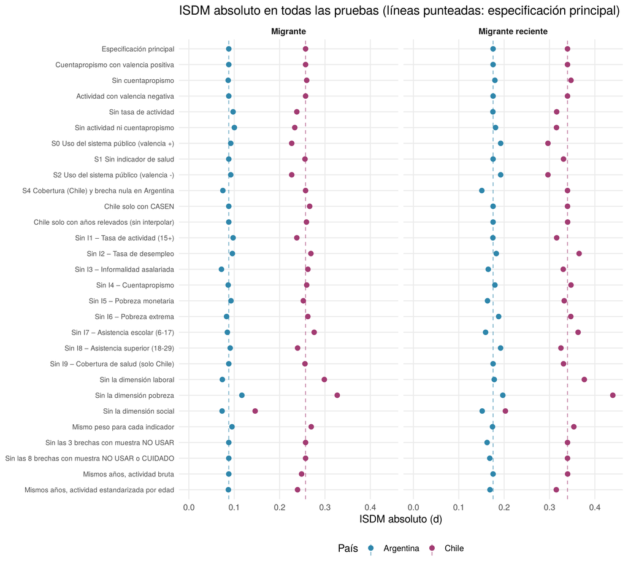

```r
todas %>%
  mutate(grupo = grupo_es[grupo], prueba = fct_inorder(prueba)) %>%
  filter(familia != "Escala") %>%
  ggplot(aes(abs_d, fct_rev(prueba), colour = pais)) +
  geom_vline(data = principal %>% mutate(grupo = grupo_es[grupo]),
             aes(xintercept = abs_d, colour = pais), linetype = "dashed", alpha = 0.6) +
  geom_point(size = 2.3) +
  facet_wrap(~ grupo) +
  scale_colour_manual(values = colores_pais) +
  scale_x_continuous(limits = c(0, NA)) +
  labs(x = "ISDM absoluto (d)", y = NULL, colour = "País",
       title = "ISDM absoluto en todas las pruebas (líneas punteadas: especificación principal)") + tema +
  theme(axis.text.y = element_text(size = 8))
```

# 8 Composición de las poblaciones y estructura etaria

```r
composicion %>%
  transmute(País = pais, Grupo = grupo, `Edad media` = edad_media, `% menor de 15` = pct_menor_15,
            `% 15-64` = pct_15_64, `% 65+` = pct_65_mas, `% mujeres` = pct_mujeres,
            `% reciente` = pct_reciente, `% limítrofe` = pct_limitrofe,
            `25+ hasta secundaria incompleta` = `educ25_Hasta secundaria incompleta`,
            `25+ secundaria completa o superior incompleta` = `educ25_Secundaria completa o superior incompleta`,
            `25+ superior completa` = `educ25_Superior completa`) %>%
  tabla("Tabla A3. Composición de la población no migrante, migrante y migrante reciente. Argentina y Chile, promedio 2015–2024 (%)", digits = 1)
```

Tabla A3. Composición de la población no migrante, migrante y migrante reciente. Argentina y Chile, promedio 2015–2024 (%)

| País | Grupo | Edad media | % menor de 15 | % 15-64 | % 65+ | % mujeres | % reciente | % limítrofe | 25+ hasta secundaria incompleta | 25+ secundaria completa o superior incompleta | 25+ superior completa |
| --- | --- | --- | --- | --- | --- | --- | --- | --- | --- | --- | --- |
| Argentina | No migrante | 34,4 | 23,3 | 64,8 | 12,0 | 51,5 | — | — | 39,5 | 38,6 | 21,9 |
| Argentina | Migrante | 47,8 | 4,9 | 70,5 | 24,7 | 55,2 | 10,0 | 62,4 | 49,2 | 33,0 | 17,8 |
| Argentina | Migrante reciente | 30,9 | 13,9 | 82,2 | 3,9 | 52,8 | — | — | 12,7 | 32,9 | 54,4 |
| Chile | No migrante | 37,4 | 19,5 | 66,5 | 14,0 | 51,6 | — | — | 37,6 | 37,3 | 25,1 |
| Chile | Migrante | 32,2 | 13,7 | 83,3 | 3,0 | 51,0 | 49,3 | — | 19,2 | 44,4 | 36,3 |
| Chile | Migrante reciente | 29,5 | 15,8 | 82,3 | 1,9 | 50,1 | — | — | 19,7 | 42,0 | 38,3 |

La tasa de actividad estandarizada aplica las tasas específicas por grupos quinquenales de edad de cada grupo migrante a la estructura etaria de la población no migrante del mismo país y año (método directo). En Chile se usa la CASEN, porque la ENE no ofrece microdatos, por lo que los valores brutos difieren levemente de los de la Tabla 1.

```r
actividad %>%
  transmute(País = pais, Grupo = grupo, `Tasa no migrante` = tasa_no_migrante,
            `Tasa bruta` = tasa_bruta, `Tasa estandarizada` = tasa_estandarizada,
            `Brecha bruta (pp)` = brecha_bruta, `Brecha estandarizada (pp)` = brecha_estandarizada) %>%
  tabla("Tabla A4. Tasa de actividad de la población de 15 años y más, bruta y estandarizada por edad. Argentina y Chile, promedio 2015–2024 (%)", digits = 1)
```

Tabla A4. Tasa de actividad de la población de 15 años y más, bruta y estandarizada por edad. Argentina y Chile, promedio 2015–2024 (%)

| País | Grupo | Tasa no migrante | Tasa bruta | Tasa estandarizada | Brecha bruta (pp) | Brecha estandarizada (pp) |
| --- | --- | --- | --- | --- | --- | --- |
| Argentina | Migrante | 60,7 | 59,5 | 61,1 | 1,3 | -0,4 |
| Argentina | Migrante reciente | 60,7 | 67,6 | 59,1 | -6,9 | 1,6 |
| Chile | Migrante | 59,6 | 80,5 | 69,5 | -21,0 | -10,0 |
| Chile | Migrante reciente | 59,6 | 80,8 | 67,5 | -21,2 | -7,9 |

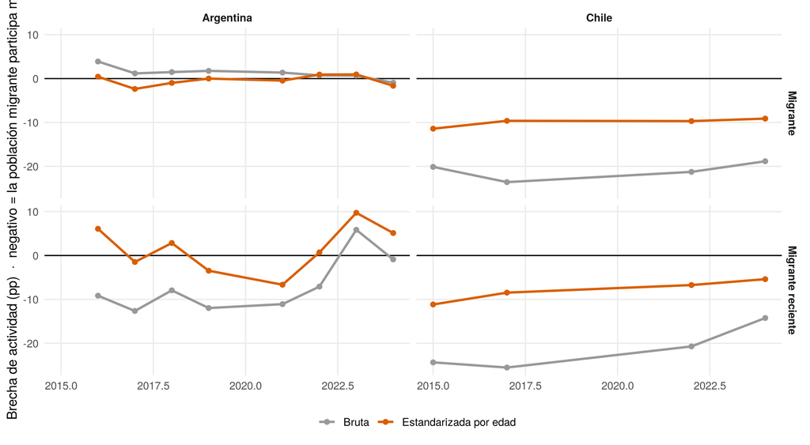

```r
actividad_a %>%
  select(pais, anio, grupo, Bruta = brecha_bruta, `Estandarizada por edad` = brecha_estandarizada) %>%
  pivot_longer(c(Bruta, `Estandarizada por edad`), names_to = "medida", values_to = "brecha") %>%
  ggplot(aes(anio, brecha, colour = medida)) +
  geom_hline(yintercept = 0, linewidth = 0.5) +
  geom_line(linewidth = 1) + geom_point(size = 1.8) +
  facet_grid(grupo ~ pais) +
  scale_colour_manual(values = c("Bruta" = "#999999", "Estandarizada por edad" = "#D95F02")) +
  labs(x = NULL, y = "Brecha de actividad (pp)  ·  negativo = la población migrante participa más", colour = NULL) + tema
```

# 9 Calidad muestral

```r
calidad %>% count(pais, grupo, semaforo) %>%
  pivot_wider(names_from = semaforo, values_from = n, values_fill = 0) %>%
  rename(País = pais, Grupo = grupo) %>%
  tabla("Cantidad de estimaciones (indicador × año) por categoría")
```

Cantidad de estimaciones (indicador × año) por categoría

| País | Grupo | OK | CUIDADO | NO USAR |
| --- | --- | --- | --- | --- |
| Argentina | Migrante | 56 | 0 | 0 |
| Argentina | Migrante reciente | 48 | 5 | 3 |
| Argentina | No migrante | 56 | 0 | 0 |
| Chile | Migrante | 32 | 0 | 0 |
| Chile | Migrante reciente | 32 | 0 | 0 |
| Chile | No migrante | 32 | 0 | 0 |

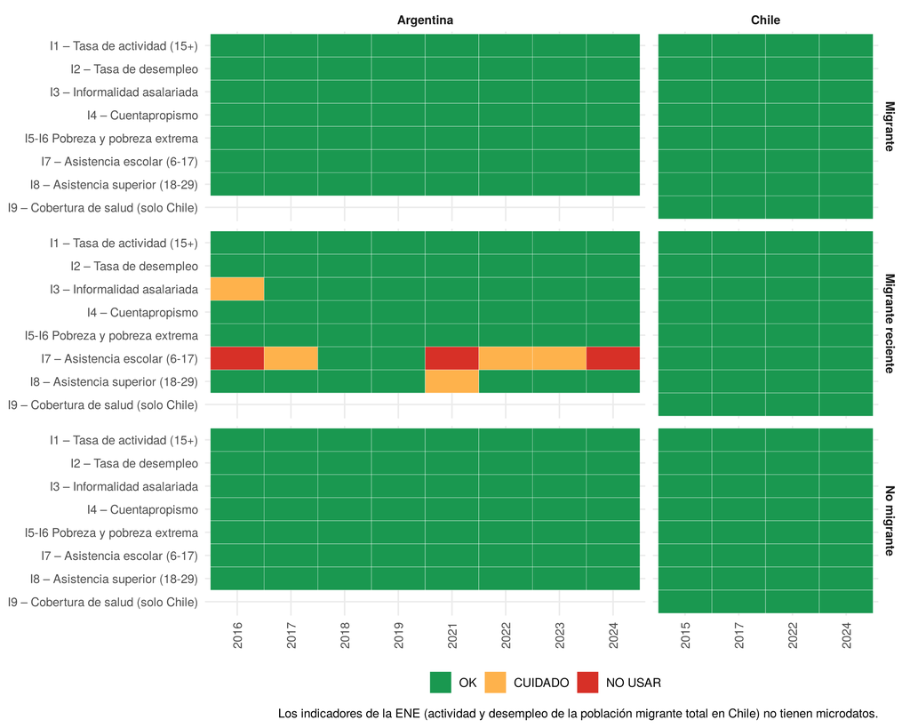

```r
calidad %>%
  mutate(indicador = coalesce(ind_es[indicador], recode(indicador, I5_I6_pobreza = "I5-I6 Pobreza y pobreza extrema")),
         semaforo = factor(semaforo, levels = c("OK", "CUIDADO", "NO USAR"))) %>%
  ggplot(aes(factor(anio), fct_rev(indicador), fill = semaforo)) +
  geom_tile(colour = "white") +
  facet_grid(grupo ~ pais, scales = "free_x", space = "free_x") +
  scale_fill_manual(values = c("OK" = "#1A9850", "CUIDADO" = "#FEB24C", "NO USAR" = "#D73027"), drop = FALSE) +
  labs(x = NULL, y = NULL, fill = NULL,
       caption = "Los indicadores de la ENE (actividad y desempleo de la población migrante total en Chile) no tienen microdatos.") + tema +
  theme(axis.text.x = element_text(angle = 90, vjust = 0.5))
```

# 10 Correspondencia con el artículo

```r
tribble(
  ~`En el artículo`, ~`Archivo`, ~`Paso`,
  "Gráfico 1", "output/contexto/stock_migratorio_arg_chl.png", "00",
  "Gráficos A1 y A2", "output/contexto/gdp_per_capita_arg_chl_media.png, gini_arg_chl_media.png", "00",
  "Tablas 1, 2 y 3", "output/isdm/brechas_por_indicador.csv", "07",
  "Gráficos 2, 3 y 4", "output/articulo/grafico2_laboral.png, grafico3_pobreza.png, grafico4_social.png", "09",
  "Tabla 4", "output/isdm/isdm_resumen_pais.csv", "07",
  "Gráfico 5", "output/articulo/grafico5_isdm_absoluto.png", "09",
  "Gráfico 6", "output/articulo/grafico6_subindices.png", "09",
  "Tabla A2", "output/isdm/sensibilidad_salud.csv", "07",
  "Tablas A3 y A4", "output/isdm/composicion_poblaciones.csv, actividad_estandarizada_edad.csv", "08",
  "Calidad muestral", "output/calidad/calidad_muestral.csv", "10",
  "Pruebas de robustez", "Este documento", "11"
) %>% tabla(align = "l")
```

| En el artículo | Archivo | Paso |
| --- | --- | --- |
| Gráfico 1 | output/contexto/stock_migratorio_arg_chl.png | 00 |
| Gráficos A1 y A2 | output/contexto/gdp_per_capita_arg_chl_media.png, gini_arg_chl_media.png | 00 |
| Tablas 1, 2 y 3 | output/isdm/brechas_por_indicador.csv | 07 |
| Gráficos 2, 3 y 4 | output/articulo/grafico2_laboral.png, grafico3_pobreza.png, grafico4_social.png | 09 |
| Tabla 4 | output/isdm/isdm_resumen_pais.csv | 07 |
| Gráfico 5 | output/articulo/grafico5_isdm_absoluto.png | 09 |
| Gráfico 6 | output/articulo/grafico6_subindices.png | 09 |
| Tabla A2 | output/isdm/sensibilidad_salud.csv | 07 |
| Tablas A3 y A4 | output/isdm/composicion_poblaciones.csv, actividad_estandarizada_edad.csv | 08 |
| Calidad muestral | output/calidad/calidad_muestral.csv | 10 |
| Pruebas de robustez | Este documento | 11 |

# 11 Referencias

Cohen, J. (1988). *Statistical power analysis for the behavioral sciences* (2.ª ed.). Lawrence Erlbaum.

ETI-Rafidha, Equipo de Trabajo e Investigación sobre Indicadores. (s. f.). *Indicadores de medición de derechos humanos. Aproximaciones conceptuales y avances* [Documento de trabajo] (L. Pautassi & F. Geller, Comps.). Rafidha, CONICET y Secretaría de Derechos Humanos y Pluralismo Cultural.

Grupo de Trabajo para el Análisis de los Informes Nacionales previstos en el Protocolo de San Salvador [GTPSS]. (2015). *Indicadores de progreso para la medición de derechos contemplados en el Protocolo de San Salvador* (OEA/Ser.D/XXVI.11). Organización de los Estados Americanos.

Kish, L. (1965). *Survey sampling*. John Wiley & Sons.

Kozlowski, D., Tiscornia, P., Weksler, G., Rosati, G., & Shokida, N. (2020). *eph: Argentina’s Permanent Household Survey Data and Manipulation Utilities*. https://doi.org/10.5281/zenodo.3462677

Longo, J., Busso, M., & Fernández Massi, M. (2023). Trabajar en plataformas en Argentina: Usos y valoraciones de esta nueva modalidad de trabajo. *Trabajo y Sociedad, 24*(41).

OECD & JRC. (2008). *Handbook on constructing composite indicators: Methodology and user guide*. OECD Publishing. https://doi.org/10.1787/9789264043466-en

Pautassi, L. (2010). Indicadores en materia de derechos económicos, sociales y culturales. Más allá de la medición. En V. Abramovich & L. Pautassi (Comps.), *La medición de derechos en las políticas sociales*. Editores del Puerto.

Zack, G., Schteingart, D., & Favata, F. (2020). Pobreza e indigencia en Argentina: Construcción de una serie completa y metodológicamente homogénea. *Sociedad y Economía*, (40). https://doi.org/10.25100/sye.v0i40.7990